# Preregistration analysis, Cost 2 study

Claudio Toro Serey & Joseph T. McGuire

This document follows the steps planned for the first pre-registration (https://osf.io/2rsgm/). The bullet points match the organization shown on the website as closely as possible. First, here is a restatement of the questions and hypotheses.

## 3. Research Questions

### 3.1.

Do decision makers in foraging environments integrate information about delay durations and reward amounts to produce reward-maximizing behavior?

### 3.2.

Main question: Are decisions affected differently by equivalent time periods of pure delay, cognitive effort, physical effort, and non-effortful task engagement? Do these four conditions involve different levels of subjective costs?

### 3.3.

How can we best computationally model the perceived cost of time and effort to predict choices in each condition?

## 4. Hypotheses

### 4.1.

Single-option, accept/reject decisions will be influenced by within-subject manipulations of reward magnitude and associated delay duration in line with a theoretical reward-maximizing strategy.

**4.1.1.** Participants will more frequently accept high-reward prospects than low-reward prospects.

**4.1.2.** The tendency to reject low-reward prospects will be greater in environments where rewards are associated with longer delays (handling times).

### 4.2.

Prospect acceptance rates will differ across four between-subject conditions, in which the delays associated with rewards (a) are unfilled, (b) include a cognitive effort requirement, (c) include a physical effort requirement, or (d) require a trivial level of physical effort but have matched visual stimuli to the physical effort condition.

**4.2.1.** In the cognitive effort condition, overall acceptance rates will be greater than in the unfilled-delay condition.

**4.2.2.** In the physical effort condition, overall acceptance rates will be greater than in the unfilled-delay condition, and equivalent to the cognitive effort condition.

**4.2.3.** In the trivial effort condition, acceptance rates will be equivalent to the unfilled-delay condition, and lower than in the physical effort and cognitive effort conditions.

### 4.3.

Choices will be well fit by a computational model in which the subjective opportunity cost of time is free to vary across the four between-subject conditions.

**4.3.1.** Participants will display stable preferences, meaning that the reward amounts they accept in a given timing condition will be similar throughout the experiment.

**4.3.2.** Subject-specific opportunity cost (OC) estimates will vary inversely with acceptance rates. Thus, the unfilled-delay condition will produce higher OC estimates than both effort conditions, which in turn will show no differences between them.

## 16. Analyses

### 16.1. Tests of whether decision makers integrate delay and reward information.

### 16.1.1.

*To address hypothesis 4.1., A logistic regression will be fit for each participant in order to predict trial-wise acceptances, using handling time and reward amount as predictors. The resulting beta coefficients for handling time and reward will be pooled across all participants, and we will perform a one-sample rank-sum test on each set of coefficients to examine whether the they are significantly positive or negative (compared to 0). If the group coefficients are significantly positive, it would mean that a predictor reliably increases the likelihood of acceptance. This will allow us to determine whether increments in handling time and reward amounts increased and decreased the likelihood of acceptance for each participant, respectively.*

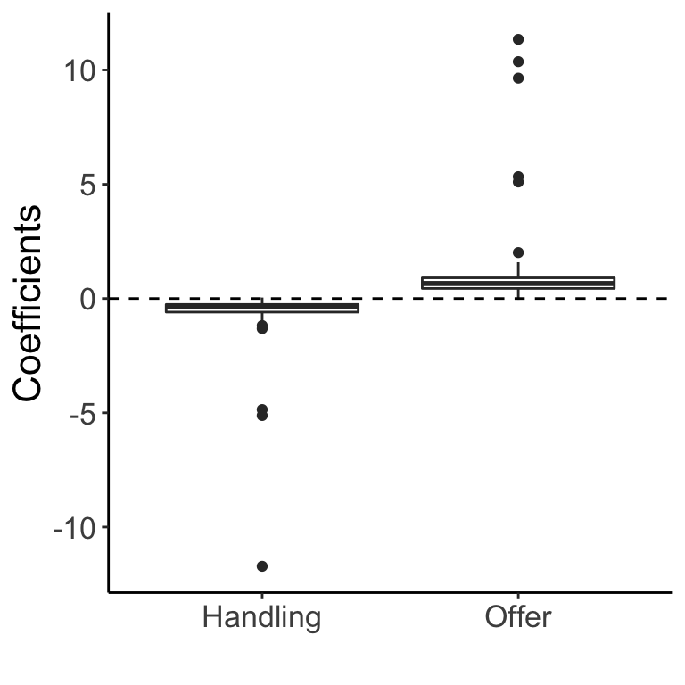

The plot shows the pooled coefficients across subjects for the effect of each predictor. The results show the expected discounting effect of increasing the handling time, as well as the increase in acceptance likelihood as a function of reward increments. We found that these coefficients were significantly different from zero for both handling (V = 33, p < 0.001) and reward (V = 3553, p < 0.001) regardless of cost condition.

### 16.1.2.

*We will perform an extension of the logistic regression from 16.1.1., this time adding an autoregressive covariate containing the number of consecutive quits prior to a given trial. In this way, we will examine the possibility that participant choices were governed by recent quitting history rather than the experimental parameters (see 11.1.3.). Coefficients not significantly different from 0 will denote that a participant did not rely on recent quitting history.*

To measure the significance of each subject’s autoregressive coefficient, we computed its CI and checked how many contained zero. By this measure, 9 out of 84 of our participants seemed to have been influenced by recent quitting. However, the autoregressive predictor did not preclude the effect of the remaininig experimental parameters.

### 16.1.3.

*A general linear model with constant, linear, and quadratic terms will be used to estimate the correspondence between proportion accepted (independent variable) and total earnings (dependent variable). No other covariates will be used, as this analysis is to confirm that over and under accepting are detrimental to total earnings. The quadratic term will be defined as the squared deviation from the optimal overall acceptance rate.*

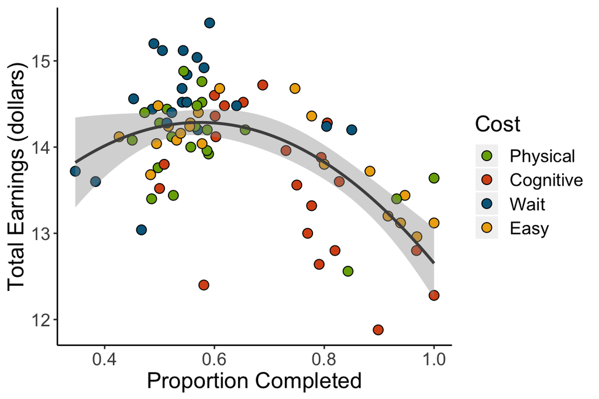

The figure shows that participants that over and unceraccepted earned less money overall, as predicted. This is supported by a significant quadratic term from the linear model (F = 25.65, Beta = -8.9921093, SE = 2.42, R-squared = 0.39; black line shows the fit). The following table shows all the results from the model.

Fitting linear model: Earnings ~ pComplete + pComplete2

|  | Estimate | Std. Error | t value | Pr(> |
| --- | --- | --- | --- | --- |
| **(Intercept)** | 11 | 1.1 | 9.9 | 1.3e-15 |
| **pComplete** | 10 | 3.4 | 3 | 0.0034 |
| **pComplete2** | -9 | 2.4 | -3.7 | 0.00038 |

### 16.1.4.

*To determine the optimality of each group’s decisions, we will perform two-sided one-sample t-tests (with mu being the optimal proporion of acceptances–either 0 or 1) to see if the proportion of acceptances for each time/reward combination was significantly different from the optimal rate (see 11.2.). This will result in 36 independent tests (3 rewards amounts, 3 handling/travel time combinations, and 4 groups), so we will correct for multiple comparisons using False Discovery Rate (FDR).*

Of the 36 tests, around 0.6388889 were significantly deviant from optimality. Most of these were from effortful groups, as the wait group just showed deviations for 2 seconds handling/4 cent, and 10 seconds handling/8 cent offers (note to self: think about a way to properly visualize these).

### 16.2. Comparisons among the four delay and effort conditions.

### 16.2.1.

*To compare preferences (hypothesis 4.2.), we will first perform a one-way ANOVA on the proportion of trials accepted using group as a factor. In addition, we will do pairwise comparisons on the proportion completed among all 4 groups using non-parametric permutation contrasts (6 tests). The same approach will be used for total earnings. This will give us an initial glimpse on the potential differences in cost among conditions.*

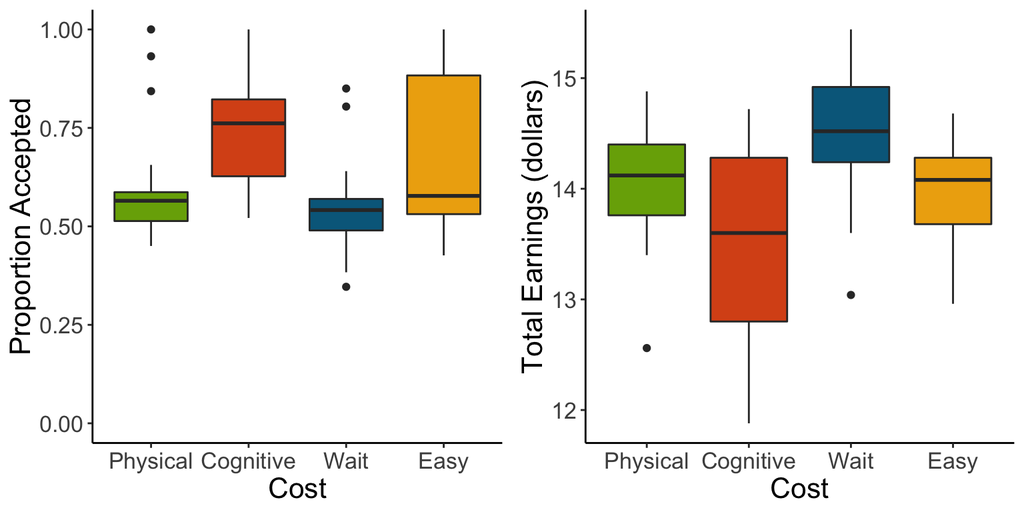

The plots show that subjects in the wait condition accepted the least and earned the most, suggesting a more optimal pattern of choices. Participants in the cognitive effort and easy conditions had higher more variable acceptance patterns, which are reflected in the comparatively low earnings. The reason why the easy condition does not show variable earnings like the cognitive effort group is probably due to the quadratic relationship between earnings and acceptances shown before.

### 16.2.2.

*In order to further look at the effect of delay, work, and rewards, we will perform a repeated measures ANOVA on the proportion completed for each combination of factors. Offer and handling time will be within-subject factors, and condition a between-subjects factor. In support of hypotheses 4.1. and 4.2., we anticipate significant main effects of handling time, reward, and cost condition, but no interactions.*

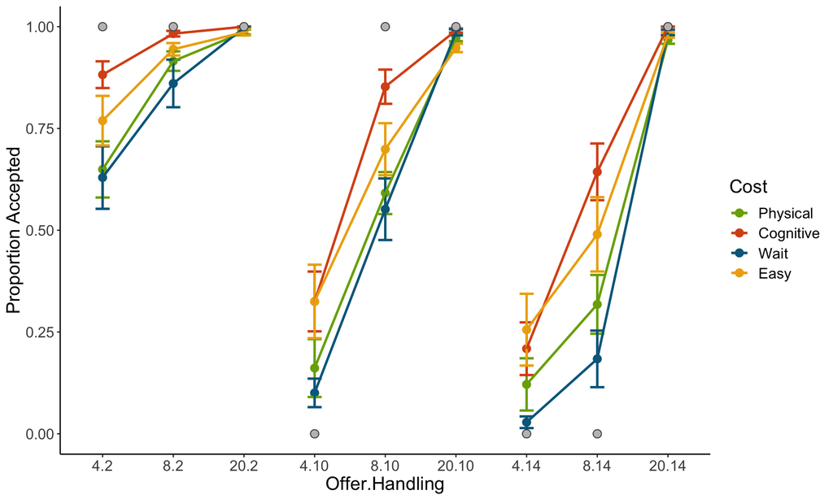

These intuitions were formally tested using a repeated measures ANOVA, whose results are presented in the table below. Overall, the analysis partially confirmed our predictions. While all main effects were significant, there was an unexpected significant condition-by-reward interaction, which could be due to the performance of the “easy” group relative to their peers. Importantly, we found that the interaction between all three main parameters was not significant, thus suggesting that the effects of handling and reward on choices were not different across groups.

Analysis of Variance Model

|  | Df | Sum Sq | Mean Sq | F value | Pr(>F) |
| --- | --- | --- | --- | --- | --- |
| **factor(Cost)** | 3 | 3.4 | 1.1 | 19 | 1.2e-11 |
| **Handling** | 1 | 1.1 | 1.1 | 18 | 2.6e-05 |
| **Offer** | 1 | 2.7 | 2.7 | 44 | 6.1e-11 |
| **factor(Cost):Handling** | 3 | 0.21 | 0.069 | 1.1 | 0.34 |
| **factor(Cost):Offer** | 3 | 1.5 | 0.49 | 8 | 2.9e-05 |
| **Handling:Offer** | 1 | 0.43 | 0.43 | 7 | 0.0082 |
| **factor(Cost):Handling:Offer** | 3 | 0.068 | 0.023 | 0.37 | 0.77 |
| **Residuals** | 736 | 45 | 0.061 | NA | NA |

### 16.2.3.

*We will compute the probability of accepting a trial with a mixed-effects logistic regression. Based on the task structure and our main question, our a priori model of interest will include cost condition, handling time, and reward amount as fixed main effects, and subject ID as a random effect. Cost condition will be modeled with three categorical terms, with the fourth condition as the reference condition. We will run three versions of the model with different reference conditions, in order to test all pairwise differences among the four cost conditions. As with 16.2.2., we anticipate significant main effects (coefficients different than zero) of handling time, reward, and cost condition. We hypothesize that the differences among cost conditions will follow the pattern described in 4.2.*

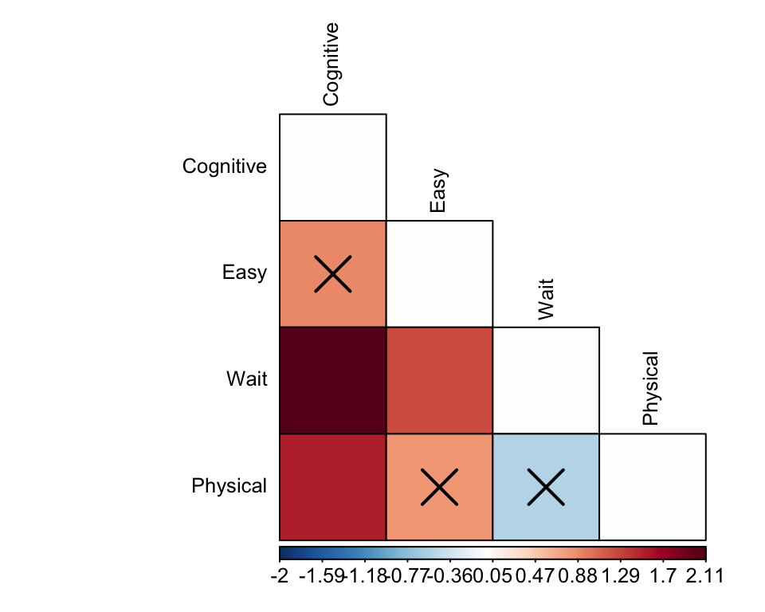

### 16.2.4.

*Next, we will examine whether the a priori model from 16.2.3. outperforms both simpler and more complex models. Unlike the individual logistic regression fits in 16.1.1., a mixed-effects approach gives us a better goodness of fit measure for model comparisons. We will determine the best model (combination of predictors) using Akaike’s Information Criterion (AIC) to determine the model that minimizes the negative log-likelihood while penalizing the addition of parameters. The regression with each combination of predictors will be fitted in the following order: 1) intercept only; 2) condition only; 3) handling time only; 4) reward only; 5) condition, handling, and reward main effects (from 16.2.3.); 6) adding a handling-by-reward interaction; and 7) adding all three possible two-way interactions. We predict that model 5 will have the lowest AIC.*

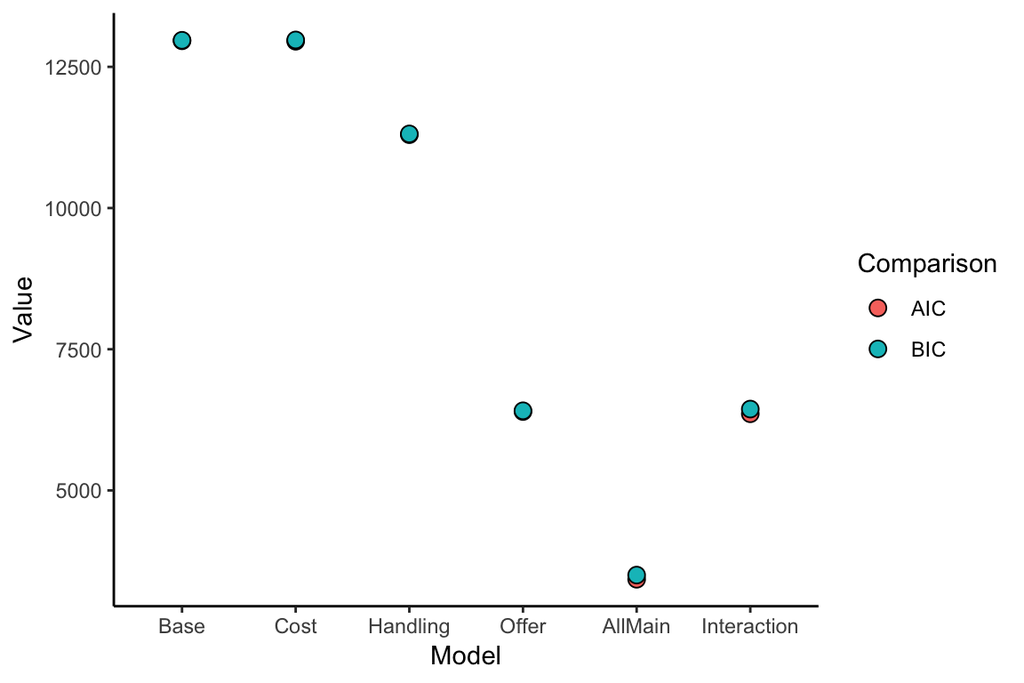

This plot shows the AIC for every model. The figure below shows AIC and BIC for all the models. As predicted, the model with all main effects reduced the deviance the most ($R^2$ = 0.82). The reduction in deviance from an intercept-only model was drastic enough that we did not compute an LRT.

### 16.3. Modeling the subjective opportunity cost in each condition.

### 16.3.1.

*Response times (RT) for quit responses will be presented in a descriptive manner in order to examine whether participants tended to quit early or late within individual trials. Each cost group’s response time distribution will contain the pooled RT across its corresponding participants, and we will display the empirical cumulative distribution functions for each condition. Short RT would suggest confident and stable decisions (in support of 4.3.1.).*

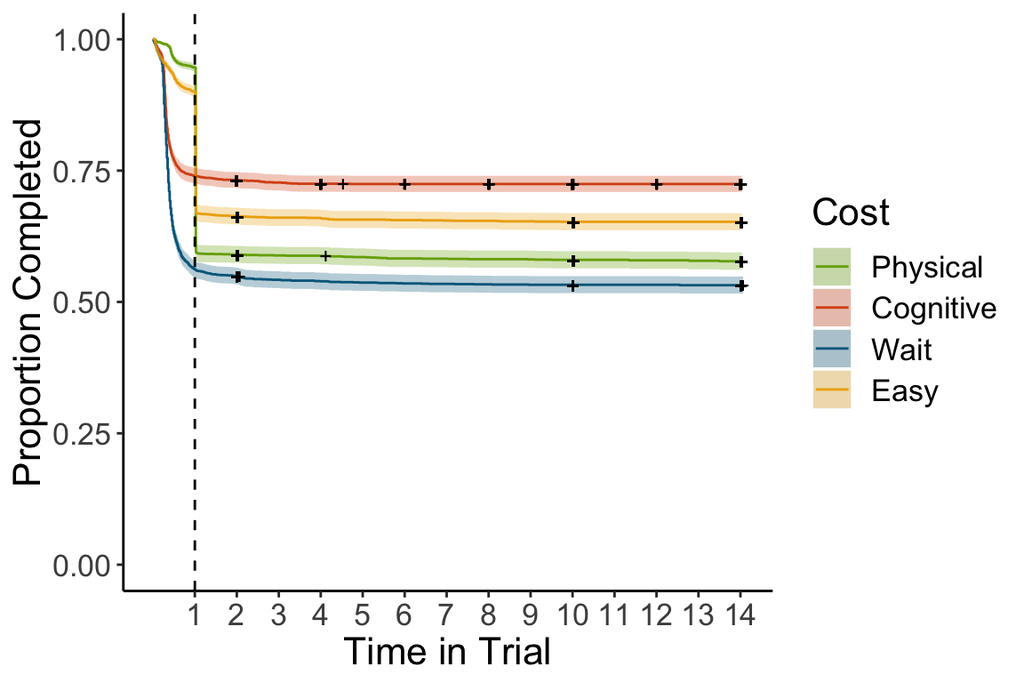

The survival curve below shows instances of quiting across a trial for all participants and handling times. Censors signal completed trials and forced quits, so most occur at the end of the three possible handling times. Participants could only quit once the trial begun. This shows that most decisions to quit happened within the first second into the handling time, and participants rarely quit during the handling time. The reason why the physical and easy condition show slightly lagged responses is that the experiment allowed a one second grace period for participants to begin gripping (marked by the dashed line). This resulted in some of them choosing to wait for that second to indicate an offer rejection. The proportion of forced quits for cognitive effort was 0.05, and 0 for the physical conditions (the censor around 4s in the physical condition was an acceptance during 2s handling that was incorrectly recorded at 4s by the experimental code).

### 16.3.2.

*In order to further examine choice stability (hypothesis 4.3.1.), we will compute each participant’s total proportion of acceptances pre- and post-midpoint. For each cost condition separately, we will fit a linear model that predicts post-midpoint acceptance from before-midpoint rates. We will report the slopes and 95% confidence intervals (CI) for each cost group. CIs containing 1 will denote that participants in that group produced consistent choices.*

The plot below shows that acceptance rates before and after the mid-point were mostly consistent, although it was more likely for participants to accept less in the second half of the experiment. **NOTE: The lines of means in the scatterplot are calculated by first computing the mean acceptances per block, then averaging those for blocks pre/post break. That’s how they match the second half of the right plot, but the linear model is computed with the overall proportion acceptances pre-post, which gives slightly different mean estimates (which is also the reason for slight mean differences in proportion accepted between these and the boxplot in 16.2.1.)**

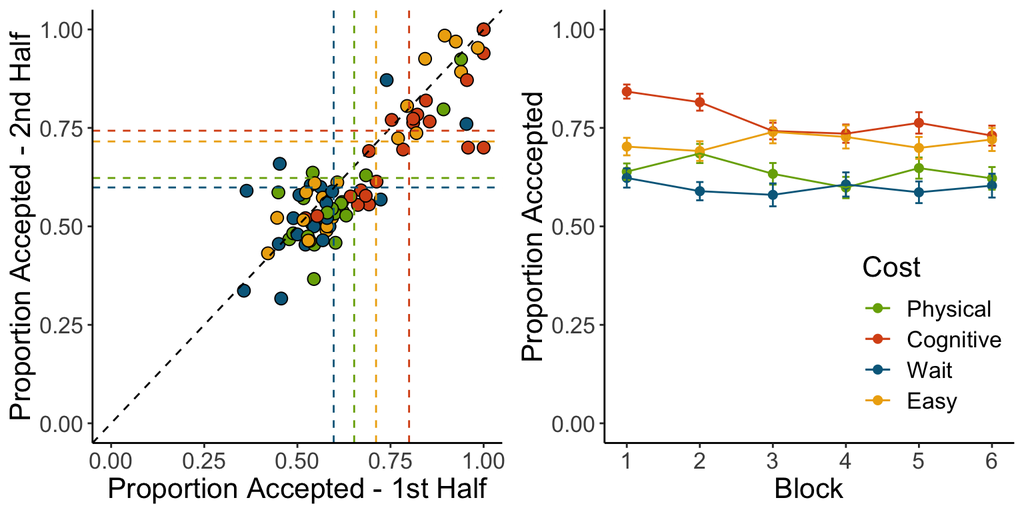

A better test is to perform a pairwise comparison between halves per cost type. Paired permutations on means of proportions showed no differences for wait and easy groups (p > 0.5), but significantly lower acceptance rates for physical (*p* = 0.0152, Cohen’s D = 0.2722762) and cognitive (*p* = 0, Cohen’s D = 0.5565946) groups. These results are more consistent with the plots above.

|  | Intercept | Coefficient | Int_CI-low | Int_CI-high | Beta_CI-low | Beta_CI-high |
| --- | --- | --- | --- | --- | --- | --- |
| **Physical** | 0.0085 | 0.92 | -0.14 | 0.69 | 0.16 | 1.2 |
| **Cognitive** | 0.081 | 0.8 | -0.11 | 0.55 | 0.28 | 1 |
| **Wait** | 0.21 | 0.6 | 0.013 | 0.25 | 0.41 | 0.95 |
| **Easy** | -0.018 | 1 | -0.12 | 0.87 | 0.089 | 1.2 |

Now let’s divide them by reward and handling amounts. The plots below show that the overall rates of acceptances remain mostly consistent across first and second halves of the experimental session.

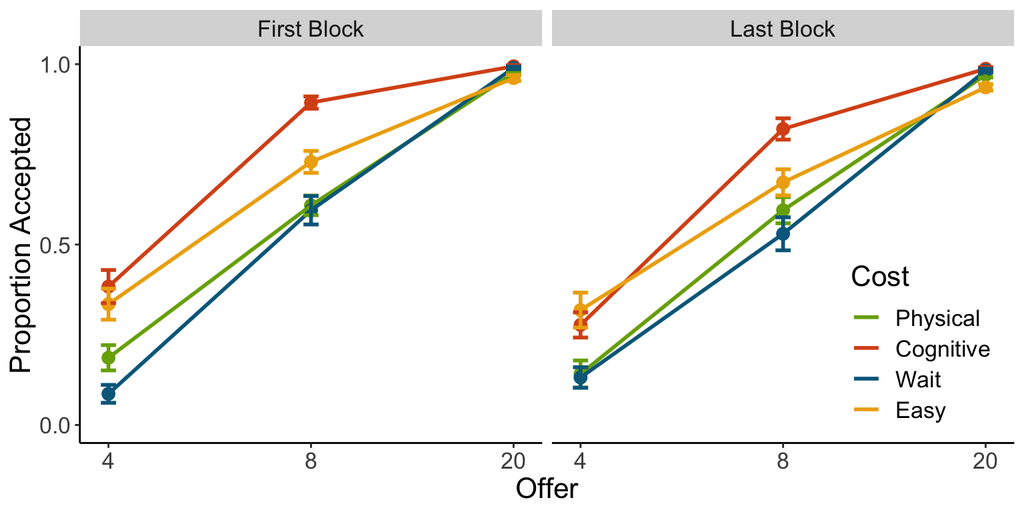

This prompted the question of whether fitting the mixed logistic model could confirm this shift in preferences. Just as before, the matrix below show the coefficient magnitude (color) and pvalues for differences based on iterating through costs as reference dummy codes.

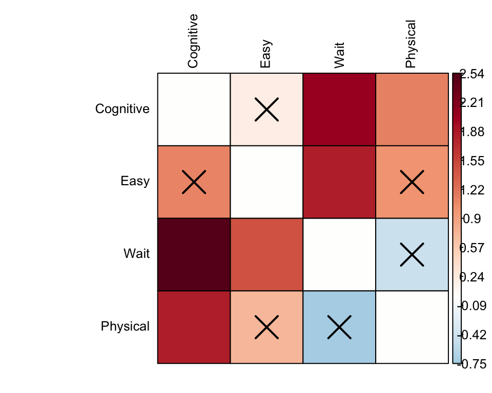

### 16.3.3.

*To estimate the subjective opportunity cost (hypothesis 4.3.2.), we will use a logistic function to model each participant’s probability of completing a trial based on the difference between the delayed reward’s magnitude and the estimated opportunity cost (OC) for each cost type. OC will be computed as the product of a free parameter (gamma) and the handling time. Both gamma and the temperature parameter of the logistic function will be estimated at the subject level, independently for each subject.*

The gamma optimization search space was bound by extreme choice values. For example, someone with an extremely high OC would not accept even the most beneficial offers, and would reject a 20 cent offer when the handling time was 2 seconds (or 20/2). Conversely, a participant experiencing low opportunity costs would accept the unbeneficial offer of 4 cents for a 14 second delay (or 4/14). The model was optimized to find the lowest value of gamma that significantly reduced the negative log likelihood. The resulting gamma values per participant are shown per group below (gray lines denote the rate of earnings under optimal behavior for all 3 timing contexts), and reflect what was seen in the previous sections: participants in the wait and physical conditions showed higher gamma values (and thus opportunity costs) than in the other two groups. Given the high variability of the easy condition, it might be worth modeling each timing context independently, or perhaps fitting the model on subgroups defined by a median split of the participants based on their acceptance rate.

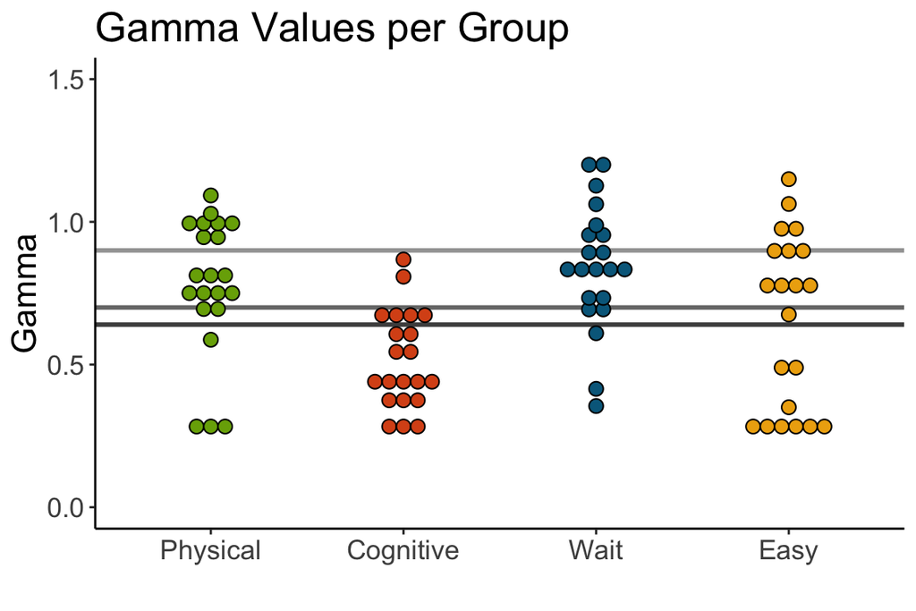

### 16.3.4.

*We will cross-validate each subject’s OC value using the pre-midpoint data for estimation, and post-midpoint choices for testing. The estimates will be used to predict acceptances in the testing sample, and the mean percent correctly predicted will be reported for each group. This will also provide information on the stability of each participant’s choices (4.3.1.).*

As can be seen below, the gamma parameter from the OC model was able to predict post-midpoint choices successfully regardless of group.

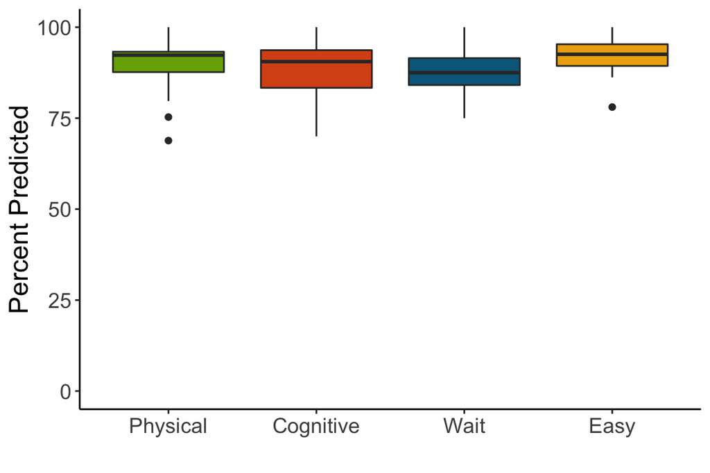

### 16.3.5.

*The OC estimates for each group will be compared using an ANOVA with condition as a factor. This will let us determine which cost type produced the highest discounting.*

The analysis of variance was significant (F = 7.56, p = < 0.001, R-squared = 0.22). Pairwise post-hoc permutations are shown in the following matrix. These results suggest that participants engaged in cognitively effortful demands experience significantly lower opportunity costs than those whose demands involve physical effort and pure delay. The reason for this is unclear, and we will work on it in the near future.

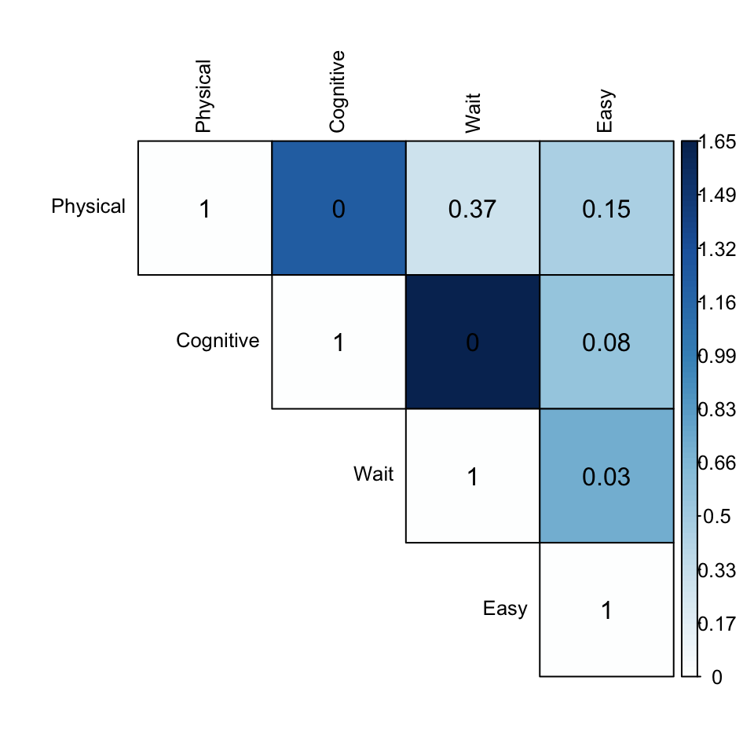

### Testing grounds

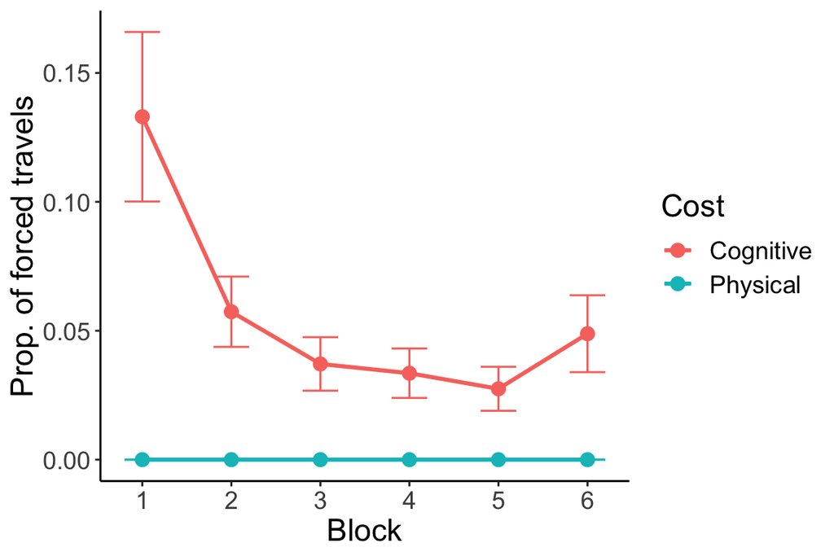

## 17. Inference criteria

These criteria will remain the same as before. For the ANOVAs, we will report the F statistic as well as the p-value. For the multiple linear regressions and logistic regression, we will report the betas (coefficients) and their associated p-values. When comparing two groups of values as in pairwise comparisons, we will use non-parametric permutation tests. We will report p-values and effect sizes, and all tests will be two-tailed. The alpha threshold for p-value evaluation will be set at 0.05.

## 18. Data exclusion

### 18.1. Missing data and quitting early.

Participants are told that they are allowed to stop participation in the study at any time without consequence. Data from participants who do not finish the experiment will be excluded from the study, and those participants will be replaced.

### 18.2. Inattentiveness

To guard against inattentiveness, a single 30 second catch trial will be placed at the end of each experimental block, merely prompting participants to press a key. From the pilot study, participants are able to respond within three seconds. Based on this, a response within three seconds will be considered as proper engagement, and a participant that fails two or more of these checks will be excluded and replaced.

### 18.3. Reasonable choices

The task is structured so that one reward amount must always be accepted. Thus, a participant who quits every trial in at least one block will be assumed not to have followed or understood task instructions, or to have disengaged from the task altogether, and will be excluded and replaced.

### 18.4. Performance

In the cognitive effort condition, participants were forced to travel if they made 2 mistakes in a trial. Any participant with more than 30% forced travels will be excluded and replaced.

## 5. Existing data

Registration prior to creation of data

## 6. Data collection

The study will use human subjects recruited from the university community, who will be recruited through the university job board. We will pay up to $30 for a session (1 hour), which includes incentive-based rewards. Participants will be ineligible if they have participated in our pilot study, or they are under 18 years of age. The study will run for however long it takes to reach our desired sample size.

## 7. Sample size

We will acquire a sample of 48 participants.

## 8. Sample size rationale?

Sample sizes were determined by means of power analysis (repeated measures ANOVA), using a significance level of 0.05, power of 0.8, a desired effect size of f = 0.5, and four groups (one for each condition). The resulting sample size was 45, which we increased to 48 in order to match the potential order of blocks and colors (section 15) while further ensuring that we have enough power.

## 9. Variables

### 9.1 The present study has three levels of manipulation.

9.1.1. Cost condition, manipulated within subjects. The conditions are (a) unfilled delay, (b) cognitive effort, and (c) physical effort. Unfilled delays will be paired with each effort type in a blocked manner (7-minute blocks). Each combination will be experienced three times.

9.1.2. Handling and travel times. These will dictate how long each trial is. The “handling time” governs how long it is necessary to wait or work to obtain a reward if a trial is accepted. The “travel time” governs how long the inter-trial interval will be, regardless of whether the trial is accepted. Participants will know that the handling time will be always 10 seconds, and the travel time 6 seconds (matching one of the between-group experiment conditions).

9.1.3. Offer magnitude, manipulated within-subject across individual trials. On each trial, participants will learn the amount of money they can earn if they complete the trial (i.e. 4, 8, or 20 cents). The amounts will be sampled uniformly, while guaranteeing that each participant experiences each amount at least twice during each block.

## 10. Measured variables

### 10.1. Behavioral variables

10.1.1. Choice (complete or quit a given trial).

10.1.2. Response times.

10.1.3. Total earnings.

10.1.3. Performance in the cognitive effort tasks (right or wrong answer).

10.1.4. Grip force throughout the experiment and maximum grip strength (physical effort condition).

### 10.2. Questionnaire

10.2.1. Age.

10.2.2. Gender.

10.2.3. Post-experimental oral assessment of choice strategy adoption. We will ask participants the following: “Did you follow a specific acceptance strategy? If so, what was it?” and “Which condition felt most effortful to you?”. Answers will be written down by the experimenter, and recorded on an excel spreadsheet.

## 11. Indices

### 11.1. Behavioral data

11.1.1. Proportion of prospects accepted.

11.1.2. Percentage of cognitive effort trials with above-threshold errors (over 2 errors), in which participants are forced to travel to the next trial.

### 11.2. Optimal behavior

The theoretical opportunity cost of time will be calculated for each handling/travel/reward acceptance combination in order to assess choice optimality. This measure is computed as the cents per second possible when consistently accepting only certain reward amounts (e.g. 8 and 20 cents) in a given timing condition. This ground truth measure is independent of cost type, allowing us to assess subject optimality.

## 12. Study type

Experiment - A researcher randomly assigns treatments to study subjects, this includes field or lab experiments. This is also known as an intervention experiment and includes randomized controlled trials.

## 13. Blinding

No blinding is involved in this study.

## 14. Study design

The present study complements our previous one, which evaluated cost types through a between-group design. Many of the details remain the same. However, this time every participant will experience all forms of cost (delay, physical effort, and cognitive effort). Delay trials will be intermixed with both physical and cognitive trials, providing a common condition to compare these effortful costs. On each trial, participants will have the opportunity to either wait or work for 10 seconds (the “handling time”) in order to earn a reward; alternatively, they can quit by pressing the space bar and skip to the next trial (which incurs a 6 second travel time). Two types of trial combinations (physical/wait and cognitive/wait) will be experienced three times by each participant in 7-minute-long, interleaved blocks. Offer amounts can be 4, 8, or 20 cents, uniformly distributed. Timing information will be disclosed at the beginning of each block, and reward prospects displayed before each trial begins.

## 15. Randomization

### 15.1. Block type

Each block will contain unfilled delay trials and trials of one effortful cost type (se 14.1). Blocks with each cost type will be interleaved, and participants will be assigned to one of two orders: beginning with a cognitive/wait or a physical/wait block. A row will be assigned to subject IDs prior to recruitment, ensuring that each order is experienced equally often. Participants will be offered a break after completing three out of the six blocks.

### 15.2. Offers and cost type

Participants can earn 4, 8, or 20 cents per trial at the cost of performing one of the three conditions. These values are sampled without replacement from a vector containing every combination of cost (effort defined by the current block, and delay) and reward. The vector is reshuffled once completed. This ensures that each combination of cost and reward is presented at least twice per block.

### 15.3. Trial color

During the offer phase, each cost type will appear in a unique color in order to ease its identification. Colors were chosen to contrast each other while being amenable to red-green color-blindness. Colors will be assigned to each cost type so that all three colors are equally paired to each cost type across participants. A row will be assigned to subject IDs prior to recruitment to indicate their block order and color pairing.